# Visualization of Crime Statistics

```r
library(data.table)
library(ggplot2)
library(reshape)
```

Loading in the San Francisco Data Set.

```r
sf <- as.data.table(read.csv("sanfrancisco_incidents_summer_2014.csv"))
```

Assign Weekend versus Weekday based on DayOfWeek

```r
wend <- function(x){
  if(x=="Saturday") return("Weekend")
  if(x=="Sunday") return("Weekend")
  return("Weekday")
}

assignment <- as.factor(unlist(lapply(sf$DayOfWeek, wend)))
nopr <- sf[,day:=assignment]
```

Look at breakdown of total crimes in each district by Weekday vs Weekend:

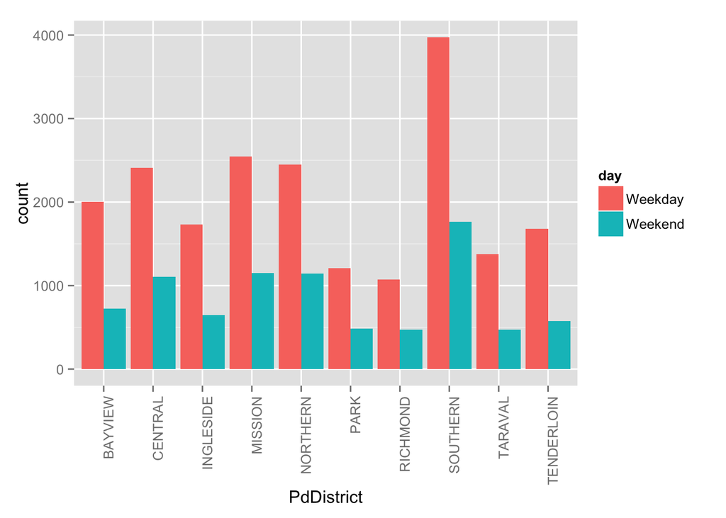

```r
ggplot(sf, aes(x=PdDistrict, fill=day)) + geom_bar(position="dodge") + theme(axis.text.x = element_text(angle = 90, hjust = 1))
```

This would be more clearly seen if instead of comapring bars, there was a percentage number.

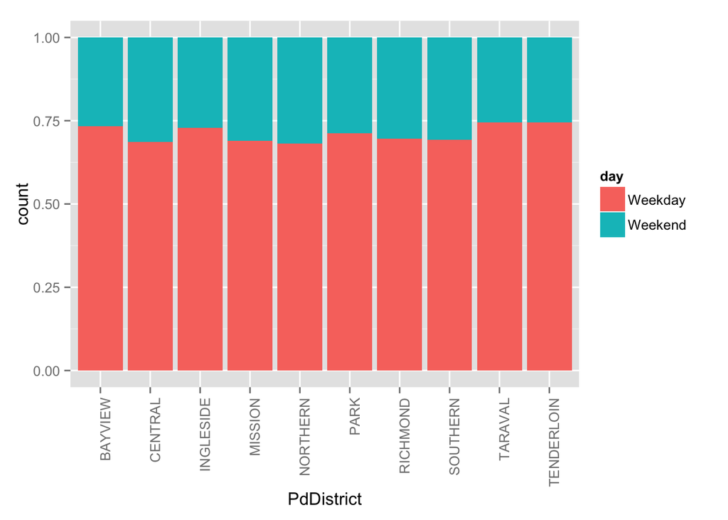

```r
ggplot(sf, aes(x=PdDistrict, fill=day)) + geom_bar(position="fill")+ theme(axis.text.x = element_text(angle = 90, hjust = 1))
```

For all districts, there are more crimes during Monday-Fri, which is 5 days, than Sat-Sunday, which is 2 days.

Looking at the number of crimes on the weekend as a filled histogram, shows that there is a skew towards the weekdays for Tenderloin, Traval, Park, Ingleside, and Bayview.

Some districts have proportionally more crime on the weekend, including Central, Mission, Northern, and Southern.

Now, we’ll investigate relative proportions of different types of crimes in a district during the week versus the weekend. Example for 1 district

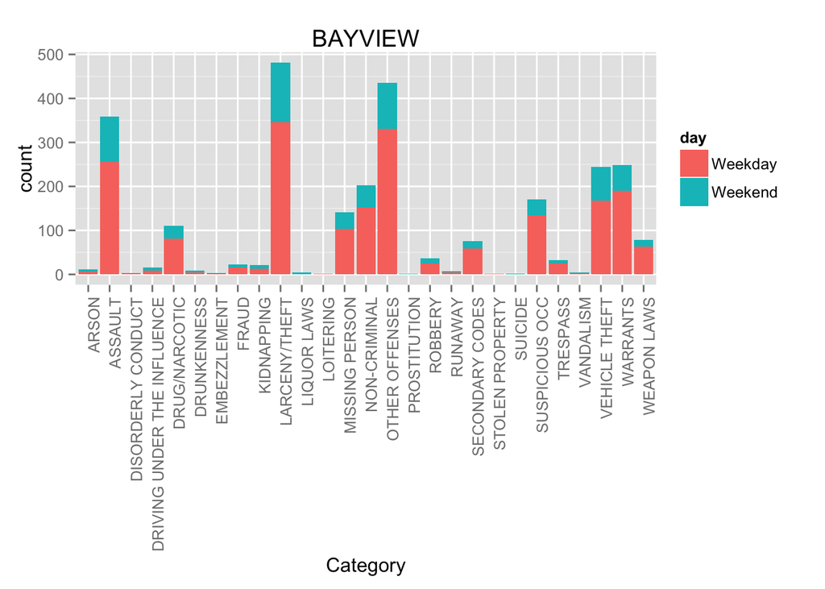

```r
districts <- levels(sf$PdDistrict)

i <- 1
plot1 <- ggplot(sf[PdDistrict==districts[i]], aes(x=Category, fill=day)) + geom_histogram()
plot1 + theme(axis.text.x = element_text(angle = 90, hjust = 1)) + ggtitle(districts[i])
```

These histograms are difficult to interpret on a district by district basis. I think graphing as proportions of weekday to weekend is better. I’m also going to focus on more common crimes to get more signal versus noise. I’m going to use an arbirary cutoff of 50 incidents to include a category.

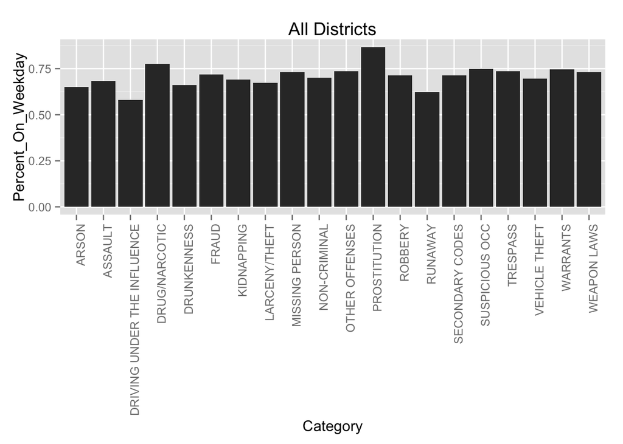

```r
sfFocused <- sf[,.(Category, PdDistrict, DayOfWeek, day)]

catCrime <- unique(sf$Category)
percent <- rep(0, length(catCrime))
totalInCat <- rep(0, length(catCrime))

#Number of each category during week and weekend:
for(i in 1:length(catCrime)){
  weekday <- nrow(sfFocused[day=="Weekday" & Category==catCrime[i]])
  weekend <- nrow(sfFocused[day=="Weekend" & Category==catCrime[i]])
  percent[i] <- weekday/(weekday+weekend)
  totalInCat[i] <- weekday+weekend
}

perPlot <- as.data.table(catCrime)
perPlot[,Percent_On_Weekday:=percent]
perPlot[,total:=totalInCat]
setnames(perPlot, c("catCrime"), c("Category"))

ggplot(perPlot[totalInCat>=50], aes(x=Category, y=Percent_On_Weekday))+ geom_bar(stat="identity") + theme(axis.text.x = element_text(angle = 90, hjust = 1)) + ggtitle("All Districts")
```

For all of the districts combined, there are three crimes that occur proportionally more often on the weekend. These three crimes are Arson, DUIs, and Runaway.

How do these crimes breakdown for the percent occuring on a weekday for each district?

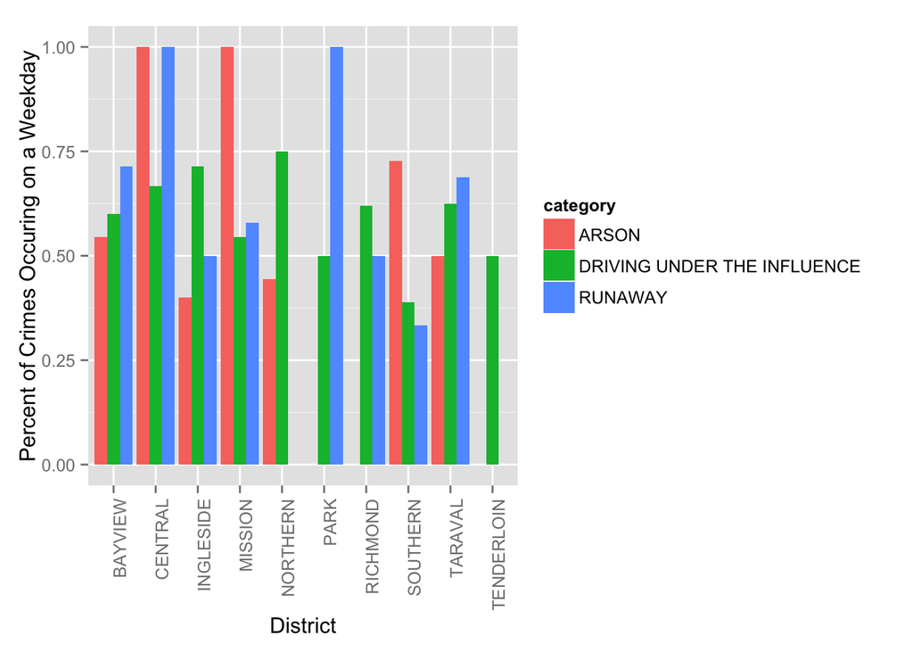

```r
focus <- c("DRIVING UNDER THE INFLUENCE", "RUNAWAY", "ARSON")

weekendCrimes <- sfFocused[Category %in% focus]

district <- unique(weekendCrimes$PdDistrict)
catCrime <- focus

dist30 <- rep(district, 3)
focus30 <- rep(focus, 10)
percent30 <- rep(0, 30)

table <- as.data.table(dist30)
table[,category:=focus30]
table[,percentWeekday:=percent30]


#Number of each category during week and weekend:
for(i in 1:length(catCrime)){
  for(j in 1:length(district)){
    weekday <- nrow(weekendCrimes[day=="Weekday" & Category==catCrime[i] & PdDistrict==district[j]])
    weekend <- nrow(weekendCrimes[day=="Weekend" & Category==catCrime[i] & PdDistrict==district[j]])
    perc <- weekday/(weekday+weekend)
    if(is.na(perc)){perc <- 0}
    table[category==catCrime[i] & dist30==district[j],percentWeekday:=perc]
  }}



ggplot(table, aes(x=dist30, fill=category, y=percentWeekday)) + geom_bar(position="dodge", stat="identity") + ylab("Percent of Crimes Occuring on a Weekday") + xlab("District") + theme(axis.text.x = element_text(angle = 90, hjust = 1))
```

The only category that has some stability by each district is “Driving under the influence.” Arson and Runaway both flucuate in their weekend versus weekday predominance depending on the district.

To drive this point home, here is a graph showing just the percentage of DUIs on weekdays. Rememeber that there are only 2 days here that count as weekends and 5 days that count as weekdays.

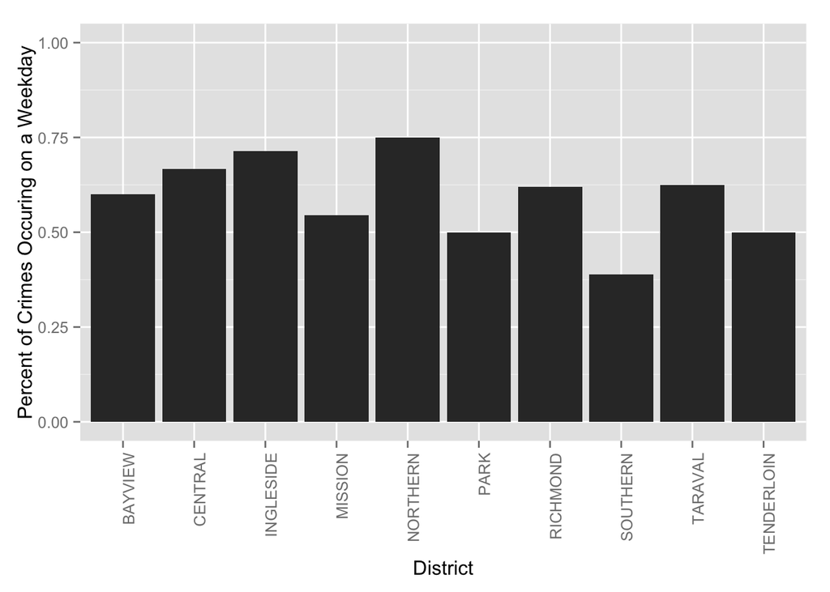

```r
ggplot(table[category=="DRIVING UNDER THE INFLUENCE"], aes(x=dist30,  y=percentWeekday)) + geom_bar(position="dodge", stat="identity") + ylab("Percent of Crimes Occuring on a Weekday") + xlab("District") + theme(axis.text.x = element_text(angle = 90, hjust = 1)) + ylim(c(0,1))
```